# Data 605 HW4

Matthew Lucich

2/12/2022

## With the attached data file, build and visualize eigenimagery that accounts for 80% of the variability. Provide full R code and discussion.

```r
library(jpeg)
library(OpenImageR)
```

## Load Images

In order to replicate, place the jpg folder of images within your working directory. First, a list of all image files is created. Then, one image is loaded (via the jpeg library) in order to obtain the dimensions of the images, which are 1200 x 2500 x 3. Finally, a 17 by 9,000,000 matrix is created, with 17 representing the number of images and 9,000,000 being the product of the dimensions of the images.

```r
# Path of images
path = file.path(getwd(), 'jpg/')
# List all images
images <- list.files(path = path, pattern = "jpg")
# Load first image (to inform the dimensions)
image <- readJPEG(paste0(path, images[1]))
# Create 17 (number of images) by 9,000,000 (product of dimensions of images) matrix
data <- matrix(0, length(images), prod(dim(image)))
```

## Convert to vectors

Here all images are looped through and converted to vectors of R, G, B components, then the transpose is taken so the result is a 9,000,000 rows and 17 columns matrix.

```r
# Loop through images and convert to R, B, G vectors
for (i in 1:length(images)) {
  im <- readJPEG(paste0(path, images[i]))
  r  <- as.vector(im[,,1])
  g  <- as.vector(im[,,2])
  b  <- as.vector(im[,,3])
  # Concat and take transpose
  data[i,] <- t(c(r, g, b))
}

df_sneakers <- as.data.frame(t(data))
```

## Center and scale

```r
scaled_sneakers <- scale(df_sneakers, center = TRUE, scale = FALSE)
```

## Compute covariance matrix

```r
sigma <- cov(scaled_sneakers)
```

## Compute eigenvectors and eigenvalues of covariance matrix

After calculating the eigenvalues and eigenvectors, the cumulative variance for the number of components included is reviewed. The results show that including the top 2 components will give us an image that accounts for ~81% of the variability.

```r
# Calculate eigenvalues and eigenvectors
eig <- eigen(sigma)
# Cumulative variance for the number of components
cum_var <- cumsum(eig$values) / sum(eig$values)
# Number of components to include in eigenimage for 81% variability
num_comp <- 2

cum_var
```

```
##  [1] 0.7149925 0.8104477 0.8478518 0.8723797 0.8916808 0.9072236 0.9205413
##  [8] 0.9331625 0.9448626 0.9543871 0.9636185 0.9714413 0.9784834 0.9851190
## [15] 0.9913699 0.9968936 1.0000000
```

## Visualize the proportion of variance that is captured in the first 17 components

Again, it can be seen that including only the top two most informative components will allow us to generate an image accounting for over 80% of the variability. Only 10 components are needed to obtain an image that accounts for 95% of the variability, demonstrating the magnitude of this dimensionality reduction technique.

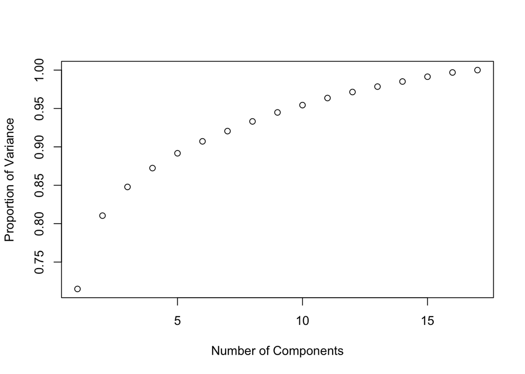

```r
plot(1:17, cum_var, xlab="Number of Components", ylab="Proportion of Variance")
```

## Compute eigenimages

Per Diego Herrero, a scaling factor is created by generating a diagonal matrix from the eigenvalues of the top 2 components, raised to the -.5 power, divided by the square root of m (rows), minus 1. Then, multiply the centered data (scaled_sneakers) with the top 2 eigenvectors, then with the scaling factor. Lastly, convert into dimensions of original and select one image to display.

```r
# Compute scaling factor
scaling_sneakers <- diag(eig$values[1:num_comp]^(-1/2)) / (sqrt(nrow(scaled_sneakers)-1))
# Multiply centered matrix by top 2 components, then by scaling factor
eigensneakers <- scaled_sneakers %*% eig$vectors[,1:num_comp] %*% scaling_sneakers
# Convert to dimensions of original images, and select one image to display
eigenimage <- array(eigensneakers[,2], dim(image))
```

## Display eigenimage

Accounts for ~81% of the variability.

[figure not shown]

```r
imageShow(eigenimage)
```

## References

[Face Recognition using Eigenfaces by Diego Herrero](https://rpubs.com/dherrero12/543854)

[Simple Image Classifier with Eigenfaces](https://rpubs.com/JanpuHou/469414)

[SVD and facial recognition (eigenfaces)](http://faculty.washington.edu/sbrunton/me565/pdf/L29secure.pdf)

[Singular Value Decomposition YouTube Course](https://www.youtube.com/playlist?list=PLMrJAkhIeNNSVjnsviglFoY2nXildDCcv)